# Consequências Oriundas da Pandemia da Covid-19 nos Estudantes Universitários Brasileiros

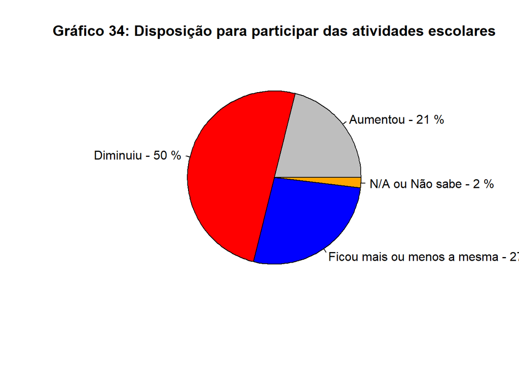

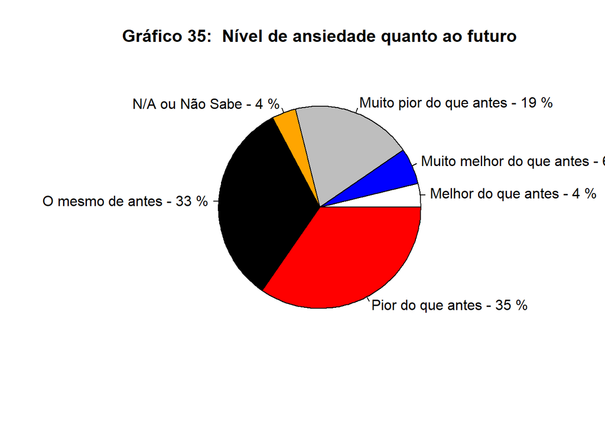

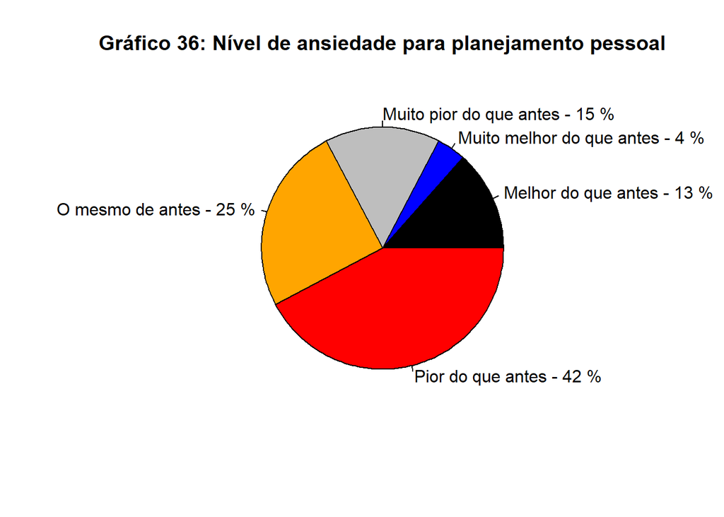

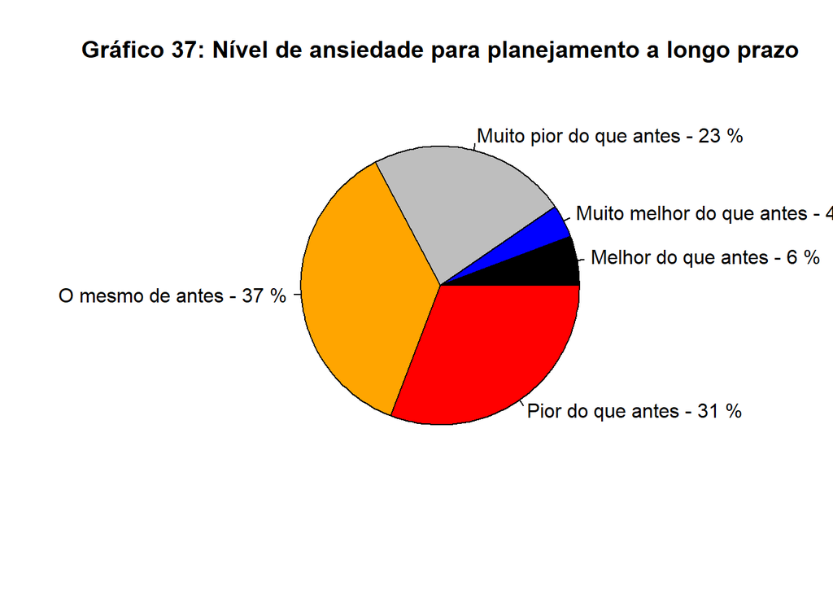

## ————————————————–

## Opinião dos alunos sobre as dificuldades - principais palavras utilizadas

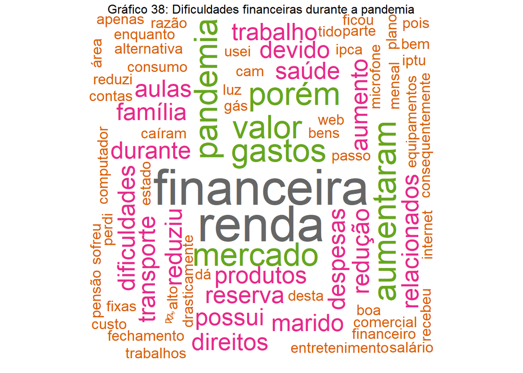

```
## [1] "Principais ocorrências de palavras das dificuldades financeiras durante a pandemia"
```

```
## [1] "financeira = 5"
## [1] "renda = 5"
## [1] "aumentaram = 3"
## [1] "gastos = 3"
## [1] "pandemia = 3"
## [1] "mercado = 3"
## [1] "valor = 3"
## [1] "porém = 3"
```

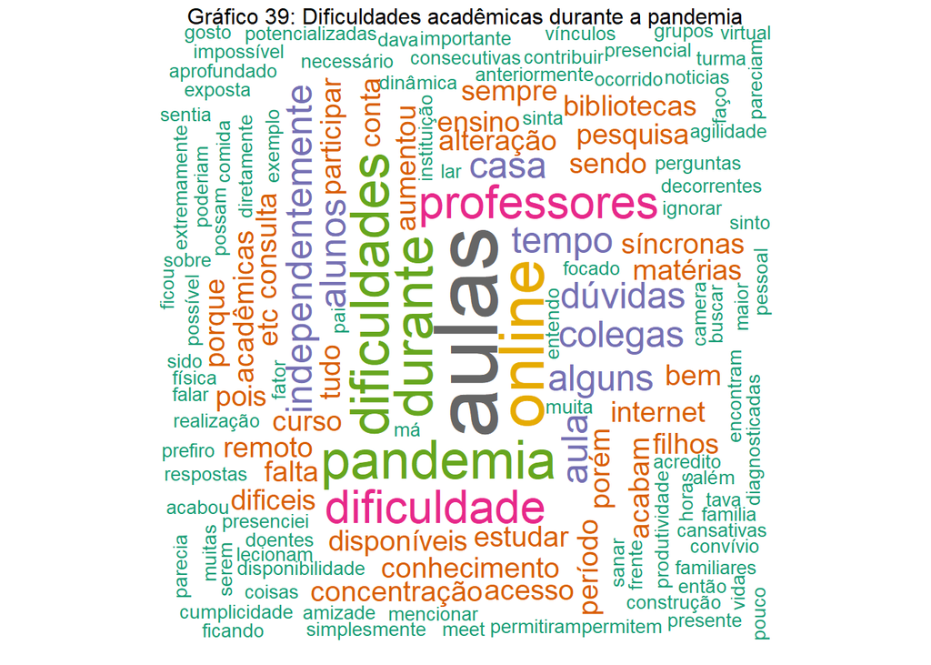

```
## [1] "Principais ocorrências de palavras das dificuldades acadêmicas durante a pandemia"
```

```
## [1] "aulas = 9"
## [1] "online = 6"
## [1] "durante = 5"
## [1] "dificuldades = 5"
## [1] "pandemia = 5"
## [1] "professores = 4"
## [1] "dificuldade = 4"
## [1] "tempo = 3"
## [1] "alguns = 3"
## [1] "alunos = 3"
## [1] "colegas = 3"
## [1] "dúvidas = 3"
## [1] "independentemente = 3"
## [1] "aula = 3"
## [1] "casa = 3"
```

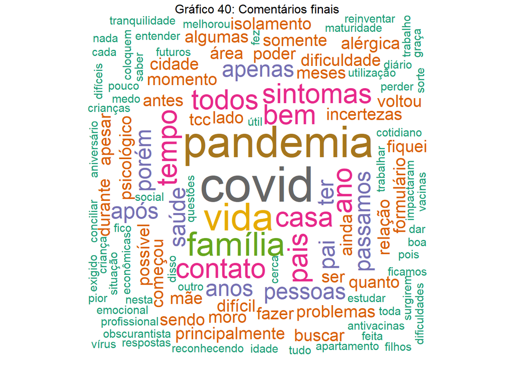

```
## [1] "Principais ocorrências de palavras nos comentários finais"
```

```
## [1] "covid = 8"
## [1] "pandemia = 7"
## [1] "vida = 6"
## [1] "família = 5"
## [1] "casa = 4"
## [1] "tempo = 4"
## [1] "bem = 4"
## [1] "pais = 4"
## [1] "todos = 4"
## [1] "ano = 4"
## [1] "contato = 4"
## [1] "sintomas = 4"
## [1] "saúde = 3"
## [1] "anos = 3"
## [1] "pai = 3"
## [1] "passamos = 3"
## [1] "porém = 3"
## [1] "ter = 3"
## [1] "apenas = 3"
## [1] "pessoas = 3"
## [1] "após = 3"
```

## Sobras ?

[figure not shown]

## Resultados e Discussão

Após a análise dos dados oriundos do questionário, foi observado que as respostas recebidas não estão totalmente distantes da realidade brasileira após período crítico de pandemia. Porém, deve-se ressaltar alguns tópicos que chamam a atenção por revelarem informações sobre dificuldades que, até então, pareciam representar uma parcela distante da população comparada à bolha social de cada indivíduo.  
Como primeiro exemplo, deve-se citar os 2% universitários que não migraram para o ensino virtual. Esse valor ainda foi superior que o identificado em escolas públicas e particulares, segundo pesquisa divulgada pela Agência Senado:

No ensino privado, 70,9% das escolas ficaram fechadas no ano passado. O número é consideravelmente menor que o da rede pública: 98,4% das escolas federais, 97,5% das municipais e 85,9% das estaduais. (Agência Senado)

“O Brasil desembolsou 15% do PIC (…) para conter os efeitos da covid no 1 ano de pandemia. (…) O endividamento dos países tende a se agravar, disse Ramalho, por outra consequência global da pandemia: a alta da inflação.” (PODER 360, 2022).

De acordo com a fonte, o Banco Mundial ainda estima que 76 milhões de pessoas entraram em 2020 para a extrema pobreza. O crescimento da desigualdade não foi causado apenas por conta da pandemia, contudo os mais vulneráveis ficaram excluídos até de medidas como o Auxílio Emergencial, já que muitos não têm acesso à internet. Segundo o IBGE, em 2021, 92,3% dos domicílios urbanos brasileiros têm acesso à Internet (PNAD, 2022). Entretanto, a desigualdade também se apresenta nesses casos, já que 100% dos lares da classe A têm ao menos um computador, e apenas 13% dos de classe D e E.  
Paralelamente, é importante destacar que boa parte dos entrevistados sofreram consequências mais brandas no âmbito educacional. Apesar de enfrentarem as mesmas dificuldades, como por exemplo, a falta de acesso à estrutura universitária em determinadas situações, de modo geral pode-se concluir que não sofreram impactos grandiosos que resultam no rompimento das atividades acadêmicas ou sua conclusão.

## Conclusão

Diante dos resultados apresentados, conclui-se que a maior parte dos estudantes universitários desta pesquisa conseguiu passar pelo período problemático da pandemia sem grandes mudanças na sua vida acadêmica.  
As universidades em que estão matriculados migraram para o ensino remoto e adaptando-se às necessidades para atender os docentes, inclusive no quesito infraestrutura, mesmo boa parte relatando algumas dificuldades em acessá-la sem grandes problemas. No quesito financeiro, ao contrário das expectativas de refletir o cenário nacional, os resultados mostraram que boa parte não sofreu grandes impactos e puderam continuar com sua rotina sem alardes. Um ponto interessante a ser citado uma vez que, mesmo possuindo fonte de renda, alguns receberam auxílio para complementar.  
Quanto ao desempenho durante o período de ensino remoto, ainda que alguns sentiram maiores dificuldades e até mesmo uma queda em sua performance, conta-se um desempenho positivo entre a maioria que manteve a mesma produtividade.  
Uma das principais limitações deste estudo é o fato de a amostra engloba basicamente estudantes de uma única universidade pública no Brasil, ou seja, os resultados podem não ser representativos de toda a população universitária em nível nacional ou até mesmo regional. No entanto, a taxa está dentro da faixa esperada de respostas pelos autores, usando pesquisas on-line com estudantes universitários.  
Considerando que não usamos uma amostragem aleatória e que a prevalência de problemas financeiros, logísticos de isolamento, de desempenho estudantil, e satisfação quanto às medidas adotadas pelas universidades, podem variar de acordo com o momento em que a avaliação foi feita, e concepção pessoal. Por conta das diferenças populacionais, e instrumentos usados, comparações entre outros levantamentos e pesquisas devem ser feitas com cautela.

## Bibliografia

BUTANTAN. Por que acontecem mutações do SARS-CoV-2 e quais as diferenças entre cada uma das variantes. 2021 . Disponível em: https://butantan.gov.br/noticias/por-que-acontecem-mutacoes-do-sars-cov-2-e-quais-as-diferencas-entre-cada-uma-das-variantes.

BRICEÑO-LEÓN, R. (2003). Quatro modelos de integração de técnicas qualitativas e quantitativas de investigação nas ciências sociais. O Clássico e o novo–tendências, objetos e abordagens em ciências sociais e saúde, 157-186. Disponível em: https://books.scielo.org/id/d5t55/pdf/goldenberg-9788575412510.pdf#page=157.

CAMPOS, Mônica Rodrigues et al. Carga de doença da COVID-19 e de suas complicações agudas e crônicas: reflexões sobre a mensuração (DALY) e perspectivas no Sistema Único de Saúde. Cadernos de Saúde Pública [online]. v. 36, n. 11. Disponível em: https://doi.org/10.1590/0102-311X00148920. ISSN 1678-4464. https://doi.org/10.1590/0102-311X00148920. Acessado 23 Janeiro 2023.

CEPAL. Pandemia provoca aumento nos níveis de pobreza sem precedentes nas últimas décadas e tem um forte impacto na desigualdade e no emprego. 2021. Disponível em: https://www.cepal.org/pt-br/comunicados/pandemia-provoca-aumento-niveis-pobreza-sem-precedentes-ultimas-decadas-tem-forte.

DE NEGRI, Fernanda et al. Ciência e Tecnologia frente à pandemia: Como a pesquisa científica e a inovação estão ajudando a combater o novo coronavírus no Brasil e no mundo. Centro de Pesquisa em Ciência, Tecnologia e Sociedade. IPEA, Brasília, DF. 23 dez. 2020. Disponível em: https://www.ipea.gov.br/cts/pt/central-de-conteudo/artigos/artigos/182-corona. Acesso em: 14 mai. 2022.

EXTRA. Migração para as escolas públicas cresce 30% na pandemia, e rede privada perde 50 mil alunos. 2021. Disponível em: https://extra.globo.com/noticias/rio/migracao-para-as-escolas-publicas-cresce-30-na-pandemia-rede-privada-perde-50-mil-alunos-25138212.html.

FIOCRUZ. 2021. Aula inaugural analisa consequências das decisões brasileiras no enfrentamento à pandemia. Disponível em: https://informe.ensp.fiocruz.br/noticias/51262.

GUSSO, Hélder Lima et al. Ensino Superior em Tempos de Pandemia: Diretrizes à Gestão Universitária. Educação & Sociedade, vol. 41, p. 1-27, set. 2020.

IBGE. PNAD Contínua - Módulo de Tecnologia de Informação e Comunicação (TIC) 2021. Disponível em: https://www.ibge.gov.br/estatisticas/multidominio/ciencia-tecnologia-e-inovacao/17270-pnad-continua.html?=&t=resultados.

JAMES, G., WITTEN, D., HASTIE, T., TIBSHIRANI, R. (2013). An Introduction to Statistical Learning. Springer.

MARIANO, Jefferson, Barcellos, Lívia I. (2017). Estratégias de gestão dos municípios em cenário de crise socioeconômica. Geografia e Pesquisa, 11(2).

MORAES, Rodrigo Fracalossi de. Medidas Legais de Incentivo ao Distanciamento Social: Comparação das Políticas de Governos Estaduais e Prefeituras das Capitais no Brasil. IPEA, Brasília, DF, abr. 2020. Disponível em: http:// https://repositorio.ipea.gov.br/handle/11058/10096. Acesso em: 13 mar. 2023.

O GLOBO. Por que o negacionismo atrapalha o combate à Covid?. 2021. Disponível em: https://oglobo.globo.com/podcast/por-que-negacionismo-atrapalha-combate-covid-1-24931788.

PODER 360. Pandemia causou recessão mais ampla que as guerras mundiais. 2022. Disponível em: https://www.poder360.com.br/economia/pandemia-causou-recessao-mais-ampla-que-as-guerras-mundiais/.

UOL. Covid: 172,6 milhões de brasileiros completam vacinação, 80,3% da população. Disponível em: https://noticias.uol.com.br/saude/ultimas-noticias/redacao/2023/01/11/vacinacao-covid-19-coronavirus-11-de-janeiro.htm?cmpid=copiaecola. Acesso em: 12 de jan. de 2023.

UNA-SUS. Organização Mundial de Saúde declara pandemia do novo Coronavírus. Disponível em: https://www.unasus.gov.br/noticia/organizacao-mundial-de-saude-declara-pandemia-de-coronavirus. Acesso em: 10 de jan. de 2023.

VEJA. As lições da pandemia de Covid-19 – que está chegando ao fim. 2021 . Disponível em: https://veja.abril.com.br/saude/os-sinais-de-que-a-pandemia-de-covid-19-vai-acabar-em-breve/.

World Health Organization. (2020). Pandemic influenza preparedness and response: A WHO guidance document. Disponível em: https://www.who.int/csr/disease/influenza/pipguidance2009/en/. Acesso em 13 mar. 2023.